# formr Instance Deployment

formr

Linode

Author

Pingfan Hu

Published

December 30, 2023

## Useful Links

| Showcase | [My formr Instance](http://172.233.238.100) [Official formr](https://formr.org) |
| --- | --- |
| Preparation | [Initial Setup with Ubuntu](https://www.digitalocean.com/community/tutorials/initial-server-setup-with-ubuntu-22-04) [Install Docker on Ubuntu](https://docs.docker.com/desktop/install/ubuntu/) |
| Deployment | [Deploy formr (Docker Version)](https://github.com/rubenarslan/formr.org/blob/master/INSTALLATION.md) |

## Abstract

This is a tutorial of deploying the [formr](https://formr.org) instance using [Ubuntu 22.04](https://www.releases.ubuntu.com/22.04/) on [Akamai](https://www.akamai.com) (prior name Linode).

This tutorial contains my personal settings. If you are following this tutorial to make your own deployment, make sure to modify based on your preference.

This tutorial consists of the following:

1. Create an Ubuntu 22.04 server using Akamai’s Linode.
2. Create user and assign `sudo` privilege.
3. Install Docker.
4. Clone and configure the formr repo.
5. Trouble-shooting.

## My Customization

| Server IP | `172.233.238.100` |
| --- | --- |
| User Name | `pingfan` |
| SQL Database Password | `0727` |
| Host Email | formrcloudgwu@gmail.com |

## Step 1 - Create the Server

### 1.1 Create the server

Proceed to [Akamai](https://www.akamai.com) and create a Linode server following these configurations:

1. **Images** - Choose Ubuntu 22.04 LTS. This is the desired version for formr instance.
2. **Region** - Choose your desired region.
3. **Linode Plan** - Choose “Dedicated CPU” and pick a plan. The formr team recommends 8 CPUs, but I only picked the basic plan.
4. **Linode Label** - Name your server as you wish. I named it as `ubuntu-formr`.
5. **Add Tags** - You may add a tag to indicate what this Linode server is for. I created a tag called `formr`.
6. **Root Password** - A `root` user will be generated for you upon server creation. This password is for accessing this `root` server. However, better create a real user and avoid using `root`. I’ll cover this later.
7. **SSH Keys** - If you haven’t done so, create an SSH key using your Terminal. Save the key pairs to a safe place. On this page, click on *Add An SSH Key* and paste the public key here.
8. Leave the rest settings as they are.

### 1.2 Access online using LISH

Once you have created your Linode server, you’ll see it in the “Linodes” section. Click on it to make sure it’s properly running. On top right corner, you’ll see a “*Launch LISH Console*” button, where *LISH* is short for *Linode Shell*. By clicking on it, you’ll open the online shell command terminal.

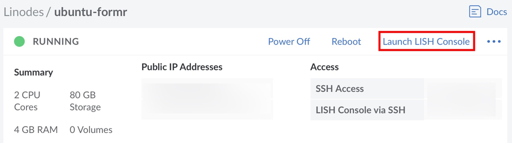

**Figure 1**: *Click on this button to launch the online shell terminal*

### 1.3 Access locally using Terminal

However, I prefer to use my local **Terminal**. Follow these steps to access this Linode using your local Terminal:

1. Launch your Terminal.
2. Type in `ssh root@your_ip_address`, and then input the root password that you created.
3. You’ll see a welcoming message if everything goes properly.

In fact, you can easily copy the SSH Access command from your Linode dashboard:

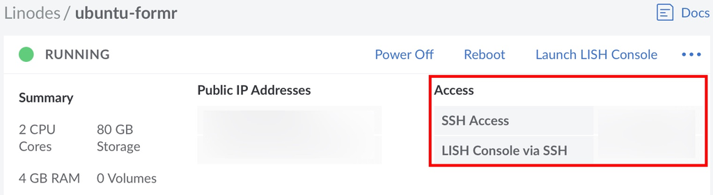

**Figure 2**: *Click on the **SSH Access** contents to directly copy the command*

Now you have created your Linode server for Ubuntu 22.04 and accessed it with your Terminal!

## Step 2 - Create the User

See the full instruction of *Digital Ocean* [here](https://www.digitalocean.com/community/tutorials/initial-server-setup-with-ubuntu-22-04), or you can follow my guides. Keep in mind that both *Digital Ocean*’s guides and my instructions contain personalizations. You need to modify to your own case.

Run the commands below *line by line* and follow the instructions when necessary. You’ll need to create the password and personal information for the new user.

```bash
# Log in as root
ssh root@your_ip_address

# Add a user called "pingfan"
adduser pingfan

# Assign sudo privilege
usermod -aG sudo pingfan

# Open a new Terminal window to login as pingfan
ssh pingfan@your_ip_address
```

Once your new user is ready, you’ll need to use it for the following steps.

> Hint: There is always a `root` user by default, but you need to avoid using it for daily purposes. This makes user creation always being our first step.

## Step 3 - Install Docker

The formr instance requires [Docker](https://www.docker.com). It is a virtual container for securely running your software. See the Docker official instructions [here](https://docs.docker.com/desktop/install/ubuntu/), or follow my steps below.

> Hint: The official instructions assume you are using a local machine with GUI, but since we are accessing a remote machine using Terminal, I slightly modified the shell commands.

**3.1** Install `gnome-terminal`

```bash
sudo apt install gnome-terminal
```

**3.2** Set up Docker’s apt repository

```bash
# Add Docker's official GPG key:
sudo apt-get update
sudo apt-get install ca-certificates curl gnupg
sudo install -m 0755 -d /etc/apt/keyrings
curl -fsSL https://download.docker.com/linux/ubuntu/gpg | sudo gpg --dearmor -o /etc/apt/keyrings/docker.gpg
sudo chmod a+r /etc/apt/keyrings/docker.gpg

# Add the repository to Apt sources:
echo \
  "deb [arch=$(dpkg --print-architecture) signed-by=/etc/apt/keyrings/docker.gpg] https://download.docker.com/linux/ubuntu \
  $(. /etc/os-release && echo "$VERSION_CODENAME") stable" | \
  sudo tee /etc/apt/sources.list.d/docker.list > /dev/null
sudo apt-get update
```

**3.3** Install the latest Docker packages

```bash
sudo apt-get install docker-ce docker-ce-cli containerd.io docker-buildx-plugin docker-compose-plugin
```

**3.4** Verify that the Docker Engine installation is successful by running the `hello-world` image

```bash
sudo docker run hello-world
```

**3.5** Download latest [DEB package](https://desktop.docker.com/linux/main/amd64/docker-desktop-4.26.1-amd64.deb?utm_source=docker&utm_medium=webreferral&utm_campaign=docs-driven-download-linux-amd64)

```bash
wget https://desktop.docker.com/linux/main/amd64/docker-desktop-4.26.1-amd64.deb
```

> Hint: Until the composition of this blog, the latest version is `docker-desktop-4.26.1-amd64.deb`.

**3.6** Install the package with `apt`

```bash
sudo apt-get update
sudo apt-get install ./docker-desktop-4.26.1-amd64.deb
```

**3.7** Launch Docker Desktop

```bash
systemctl --user start docker-desktop
```

**3.8** Check the versions

```bash
docker compose version
docker --version
docker version
```

**3.9** Enable Docker Desktop to start on login

```bash
systemctl --user enable docker-desktop
```

Now the Dock Desktop should be installed and set as auto-launch upon system start.

## Step 4 - Clone and Configure the formr Repo

See the formr official instructions [here](https://github.com/rubenarslan/formr.org/blob/master/INSTALLATION.md), or you can follow my steps below.

**4.1** Clone the formr repo

```bash
git clone https://github.com/rubenarslan/formr_dev_docker.git
```

**4.2** Change dir and run `./setup.sh`

```bash
cd formr_dev_docker
sudo ./setup.sh
```

**4.3** Configure database and domain names

```bash
sudo nano .env
```

> Hint: `nano` is the default editor of files in Terminal. After you are satisfied with your editing, you can use `Ctrl` + `O` to write out, and then `Ctrl` + `X` to exit.

You’ll need to modify the contents to meet your own personalization. Below is the official hint:

```bash
# Mysql password of root, by default a random password will be generated
MARIADB_ROOT_PASSWORD

# Mysql database name, default = formr_db
MARIADB_DATABASE

# Mysql database user, default = formr_user
MARIADB_USER

# Mysql database password of user MARIADB_USER
# By default a random password will be generated
MARIADB_PASSWORD

# The main domain of your formr instance
MAIN_DOMAIN

# Domain of formr_app. Can fill with multiple domain with separated by comma (,)
# Default value = formr.org,www.formr.org
FORMR_DOMAIN

# (Sub)domain for opencpu. Access to this domain needs basic-auth
# Default value = ocpu.formr.org
OPENCPU_DOMAIN

# Email for the ACME Let's Encrypt configuration and for the first superadmin
FORMR_EMAIL

# Default superadmin password
FORMR_PASSWORD

# formr version or branch. Default value = v0.20.6
# Please check on this link https://github.com/rubenarslan/formr.org/tags
FORMR_TAG

# defaults to Europe/Berlin
TIMEZONE
```

**4.4** Build containers and install initial schema

```bash
sudo ./build.sh
cd formr_app/formr/config
sudo nano settings.php
cd ~/formr_dev_docker
sudo docker compose restart
```

The formr instance should be installed now. You may access your formr instance by pasting your IP address to your browser.

You can access mine using [this link](http://172.233.238.100). It looks the same as the [official version](https://formr.org).

> Hint: If you want to access your formr instance via a personalized domain, you’ll need to go back to **4.3** and set the main domain, and also modify your domain by adding a new *A Record* and assign the value as your IP address.

## Step 5 - Trouble-shooting

**5.1** Hints for the `cd` command

```bash
# To change to root dir
cd

# To change to a dir by inputting relative path
# A relative path is where you start from your current dir
cd dir_name

# To change to a dir by inputting absolute path
# An absolute path disregards your current path
cd ~/dir_name
```

**5.2** Configurational files

There are 3 configurational files in formr. They can be accessed using the following commands:

```bash
# .env
cd ~/formr_dev_docker
sudo nano .env

# settings.php
cd ~/formr_dev_docker/formr_app/formr/config
sudo nano settings.php

# Session.php
cd ~/formr_dev_docker/formr_app/formr/application
sudo nano Session.php
```

**5.3** Restart Docker

After each configuration, you’ll need to restart Docker by using the following commands:

```bash
cd ~/formr_dev_docker
sudo docker compose restart
```

Back to top